# Data Cleaning, EDA, and Modeling

Jaret Stickrod

2024-11-26

```r
# Install required libraries if not already installed
if (!requireNamespace("mgcv", quietly = TRUE)) install.packages("mgcv")
if (!requireNamespace("caret", quietly = TRUE)) install.packages("caret")
if (!requireNamespace("tidyverse", quietly = TRUE)) install.packages("tidyverse")
if (!requireNamespace("dplyr", quietly = TRUE)) install.packages("dplyr")
if (!requireNamespace("ggplot2", quietly = TRUE)) install.packages("ggplot2")
if (!requireNamespace("randomForest", quietly = TRUE)) install.packages("randomForest")
if (!requireNamespace("xgboost", quietly = TRUE)) install.packages("xgboost")
```

### Research Question: How does the number of defenders in the box and number of pass rushers affect the play result?

## Data Cleaning

```r
library(dplyr)
library(tidyverse)
df <- read.csv("plays.csv")

# Filter for passing plays only
df <- df %>%
  filter(playType == "play_type_pass") %>%
  select(playResult, defendersInTheBox, numberOfPassRushers) %>%
  drop_na()

# Binning the predictors
df <- df %>%
  mutate(
    defendersInTheBox_binned = cut(defendersInTheBox, breaks = seq(4, 8, by = 1)),
    numberOfPassRushers_binned = cut(numberOfPassRushers, breaks = seq(3, 7, by = 1))
  )
str(df)
```

```
## 'data.frame':    17330 obs. of  5 variables:
##  $ playResult                : int  10 0 0 33 0 4 0 0 26 3 ...
##  $ defendersInTheBox         : int  7 7 6 6 8 7 6 7 8 8 ...
##  $ numberOfPassRushers       : int  4 4 4 5 6 4 4 4 4 3 ...
##  $ defendersInTheBox_binned  : Factor w/ 4 levels "(4,5]","(5,6]",..: 3 3 2 2 4 3 2 3 4 4 ...
##  $ numberOfPassRushers_binned: Factor w/ 4 levels "(3,4]","(4,5]",..: 1 1 1 2 3 1 1 1 1 NA ...
```

## Exploratory Data Analysis

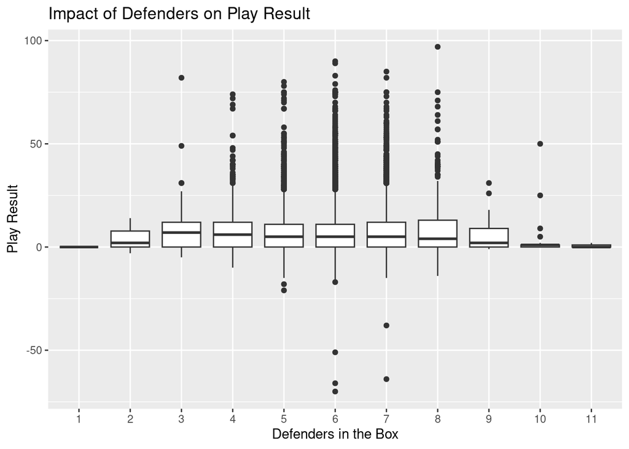

```r
##### Boxplots

library(ggplot2)

ggplot(df, aes(x = factor(defendersInTheBox), y = playResult)) +
  geom_boxplot() +
  labs(x = "Defenders in the Box", y = "Play Result", title = "Impact of Defenders on Play Result")
```

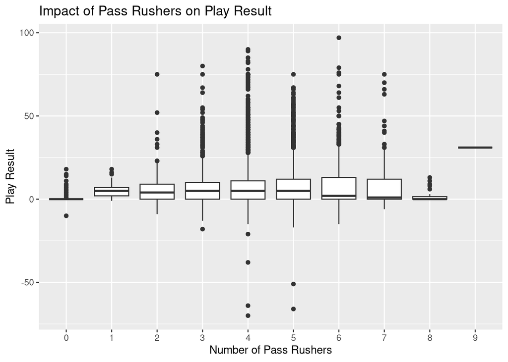

```r
ggplot(df, aes(x = factor(numberOfPassRushers), y = playResult)) +
  geom_boxplot() +
  labs(x = "Number of Pass Rushers", y = "Play Result", title = "Impact of Pass Rushers on Play Result")
```

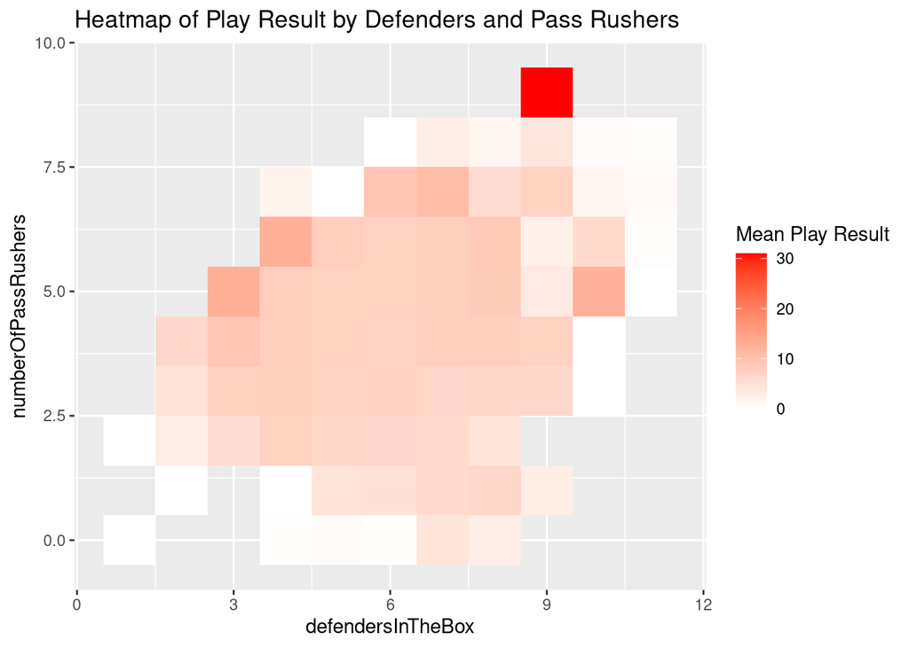

```r
##### Heatmap
heatmap_data <- df %>%
  group_by(defendersInTheBox, numberOfPassRushers) %>%
  summarise(mean_playResult = mean(playResult, na.rm = TRUE))
ggplot(heatmap_data, aes(x = defendersInTheBox, y = numberOfPassRushers, fill = mean_playResult)) +
  geom_tile() +
  scale_fill_gradient2(low = "blue", mid = "white", high = "red", midpoint = 0) +
  labs(title = "Heatmap of Play Result by Defenders and Pass Rushers", fill = "Mean Play Result")
```

```r
##### Check correlations using correlation matrix
numeric_vars <- c("playResult", "defendersInTheBox", "numberOfPassRushers")
cor_matrix <- cor(df[, numeric_vars], use = "complete.obs")
print(cor_matrix)
```

```
##                      playResult defendersInTheBox numberOfPassRushers
## playResult          1.000000000       0.005210438          0.03098937
## defendersInTheBox   0.005210438       1.000000000          0.23360649
## numberOfPassRushers 0.030989366       0.233606495          1.00000000
```

## Exploratory Modeling

```r
library(dplyr)
library(mgcv)
library(caret)
##### Splitting the Data
set.seed(123)  # reproducibility
train_index <- createDataPartition(df$playResult, p = 0.8, list = FALSE)
train_data <- df[train_index, ]
test_data <- df[-train_index, ]

##### Exploratory Modeling
# Linear Regression
lm_model <- lm(playResult ~ defendersInTheBox + numberOfPassRushers, data = train_data)

# Generalized Additive Model (GAM)
gam_model <- gam(playResult ~ s(defendersInTheBox) + s(numberOfPassRushers), data = train_data)

##### Cross-Validation
set.seed(445)
control <- trainControl(method = "cv", number = 5)  # 5-fold cross-validation

# Cross-Validation for Linear Regression
cv_lm <- train(
  playResult ~ defendersInTheBox + numberOfPassRushers,
  data = train_data,
  method = "lm",
  trControl = control
)

# Cross-Validation for GAM
cv_gam <- train(
  playResult ~ defendersInTheBox + numberOfPassRushers,
  data = train_data,
  method = "gamSpline",
  trControl = control
)
##### Model Performance on Test Data
# Predict and Evaluate Linear Regression
lm_predictions <- predict(lm_model, newdata = test_data)
lm_rmse <- sqrt(mean((lm_predictions - test_data$playResult)^2))

# Predict and Evaluate GAM
gam_predictions <- predict(gam_model, newdata = test_data)
gam_rmse <- sqrt(mean((gam_predictions - test_data$playResult)^2))

# Output Results
cat("=== Model Summaries ===\n")
```

```
## === Model Summaries ===
```

```r
cat("Linear Regression:\n")
```

```
## Linear Regression:
```

```r
print(summary(lm_model))
```

```
##
## Call:
## lm(formula = playResult ~ defendersInTheBox + numberOfPassRushers,
##     data = train_data)
##
## Residuals:
##     Min      1Q  Median      3Q     Max
## -77.321  -7.321  -2.321   3.679  88.915
##
## Coefficients:
##                     Estimate Std. Error t value Pr(>|t|)
## (Intercept)          5.78934    0.59994   9.650  < 2e-16 ***
## defendersInTheBox    0.00161    0.08767   0.018 0.985344
## numberOfPassRushers  0.38050    0.10086   3.773 0.000162 ***
## ---
## Signif. codes:  0 '***' 0.001 '**' 0.01 '*' 0.05 '.' 0.1 ' ' 1
##
## Residual standard error: 10.17 on 13862 degrees of freedom
## Multiple R-squared:  0.00109,    Adjusted R-squared:  0.0009457
## F-statistic: 7.562 on 2 and 13862 DF,  p-value: 0.0005221
```

```r
cat("\nGAM:\n")
```

```
##
## GAM:
```

```r
print(summary(gam_model))
```

```
##
## Family: gaussian
## Link function: identity
##
## Formula:
## playResult ~ s(defendersInTheBox) + s(numberOfPassRushers)
##
## Parametric coefficients:
##             Estimate Std. Error t value Pr(>|t|)
## (Intercept)  7.39567    0.08623   85.77   <2e-16 ***
## ---
## Signif. codes:  0 '***' 0.001 '**' 0.01 '*' 0.05 '.' 0.1 ' ' 1
##
## Approximate significance of smooth terms:
##                          edf Ref.df     F  p-value
## s(defendersInTheBox)   4.436  5.368 4.308 0.000498 ***
## s(numberOfPassRushers) 2.968  3.760 7.828 6.14e-06 ***
## ---
## Signif. codes:  0 '***' 0.001 '**' 0.01 '*' 0.05 '.' 0.1 ' ' 1
##
## R-sq.(adj) =  0.00376   Deviance explained = 0.43%
## GCV = 103.15  Scale est. = 103.09    n = 13865
```

```r
cat("\n=== Cross-Validation Results ===\n")
```

```
##
## === Cross-Validation Results ===
```

```r
cat("Linear Regression Cross-Validation:\n")
```

```
## Linear Regression Cross-Validation:
```

```r
print(cv_lm)
```

```
## Linear Regression
##
## 13865 samples
##     2 predictor
##
## No pre-processing
## Resampling: Cross-Validated (5 fold)
## Summary of sample sizes: 11092, 11091, 11092, 11093, 11092
## Resampling results:
##
##   RMSE      Rsquared     MAE
##   10.16613  0.001126379  7.185277
##
## Tuning parameter 'intercept' was held constant at a value of TRUE
```

```r
cat("\nGAM Cross-Validation:\n")
```

```
##
## GAM Cross-Validation:
```

```r
print(cv_gam)
```

```
## Generalized Additive Model using Splines
##
## 13865 samples
##     2 predictor
##
## No pre-processing
## Resampling: Cross-Validated (5 fold)
## Summary of sample sizes: 11092, 11093, 11092, 11092, 11091
## Resampling results across tuning parameters:
##
##   df  RMSE      Rsquared     MAE
##   1   10.16291  0.001209529  7.185478
##   2   10.15990  0.001831320  7.181935
##   3   10.15679  0.002437124  7.176742
##
## RMSE was used to select the optimal model using the smallest value.
## The final value used for the model was df = 3.
```

```r
cat("\n=== Test Set Performance ===\n")
```

```
##
## === Test Set Performance ===
```

```r
cat("Linear Regression RMSE:", lm_rmse, "\n")
```

```
## Linear Regression RMSE: 9.847673
```

```r
cat("GAM RMSE:", gam_rmse, "\n")
```

```
## GAM RMSE: 9.834928
```

1. Both linear regression and GAM explain very little variance in `playResult`, with low R-squared values and high RMSE.
2. The number of pass rushers shows a stronger relationship with `playResult`, with GAM indicating non-linearity, while defenders in the box has minimal impact.
3. The GAM slightly outperforms linear regression, but the improvement is not significant.

```r
library(randomForest)
library(caret)

clean_df <- na.omit(df[, c("defendersInTheBox", "playResult", "numberOfPassRushers")])

set.seed(123)
train <- createDataPartition(clean_df$playResult, p = 0.8, list = FALSE)
train_data <- clean_df[train, ]
test_data <- clean_df[-train, ]

rf <- randomForest(playResult ~ defendersInTheBox + numberOfPassRushers, data = train_data, ntree = 100)

prediction <- predict(rf, test_data)

actual <- factor(round(test_data$playResult))
predicted <- factor(round(prediction), levels = levels(actual))

cm <- confusionMatrix(predicted, actual)
cm
```

[output not shown]

[output cut: 515 more lines]

[output not shown]

```r
importance(rf)
```

```
##                     IncNodePurity
## defendersInTheBox        4881.880
## numberOfPassRushers      6791.184
```

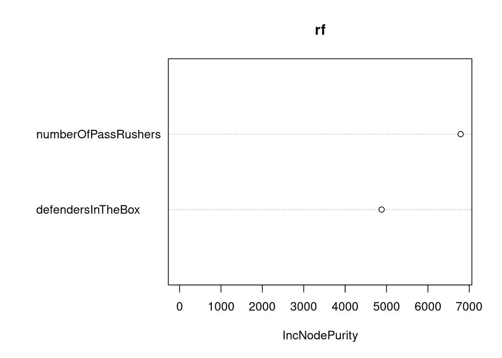

```r
varImpPlot(rf)
```

The random forest is not a good model to use given it can only accurately predict the relationship 4.53% of the time. Since numberOfPassRushers has an importance score of 6791 and defendersInTheBox has an importance score of 4881 the model is suggesting that numberOfPassRushers is more influential in predicting the outcome of a play.

```r
library(xgboost)
library(dplyr)

set.seed(123)

response <- "playResult"
predictors <- c("defendersInTheBox", "numberOfPassRushers")

plays <- df %>%
  mutate(across(all_of(c(response, predictors)), as.numeric))

train <- createDataPartition(plays[[response]], p = 0.8, list = FALSE)
train_data <- plays[train, ]
test_data <- plays[-train, ]

train_x <- as.matrix(train_data[, predictors])
train_y <- train_data[[response]]

test_x <- as.matrix(test_data[, predictors])
test_y <- test_data[[response]]

params <- list(
  bjective = "reg:squarederror",
  eta = 0.1,
  max_depth = 6,
  subsample = 0.8,
  colsample_bytree = 0.8
)

xgb <- xgboost(
  data = train_x,
  label = train_y,
  params= params,
  nrounds = 100,
  verbose = 0
)
```

```
## [16:24:00] WARNING: src/learner.cc:767:
## Parameters: { "bjective" } are not used.
```

```r
xgb_predict <- predict(xgb, test_x)

xgb_mse <- mean((test_y - xgb_predict)^2)
xgb_rmse <- sqrt(xgb_mse)

xgb_rmse
```

```
## [1] 9.83128
```

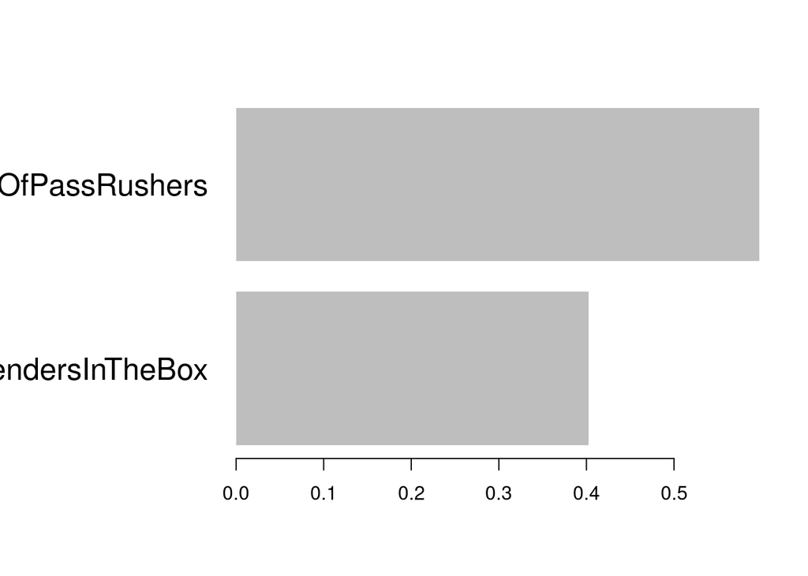

```r
importance <- xgb.importance(feature_names = predictors, model = xgb)
xgb.plot.importance(importance)
```

```r
#library(pdp)

#train_data <- data.frame(defendersInTheBox = rnorm(100),
   #                     numberOfPassRushers = rnorm(100),
   #                      playResult = rnorm(100))

#xgb_model <- xgboost(data = as.matrix(train_data[, c("defendersInTheBox", "numberOfPassRushers")]),
             #        label = train_data$playResult,
             #        nrounds = 100,
              #       objective = "reg:squarederror")

#pdp_defenders <- partial(xgb_model, pred.var = "defendersInTheBox", train = train_data)

#plot(pdp_defenders)
##Still Debugging, shows how feature affects target holding other variables constant
```

```r
library(e1071)
library(caret)

svm_model <- svm(playResult ~ defendersInTheBox,
                 data = train_data,
                 type = "eps-regression",
                 kernel = "radial")

predictions <- predict(svm_model, newdata = test_data)

if (is.numeric(test_data$playResult)) {
  rmse <- sqrt(mean((predictions - test_data$playResult)^2))
  cat("RMSE:", rmse, "\n")
} else {
  confusion <- confusionMatrix(as.factor(predictions), as.factor(test_data$playResult))
  print(confusion)
}
```

```
## RMSE: 10.14516
```